```python
from IPython.display import HTML

HTML('''<script>
code_show=true;
function code_toggle() {
 if (code_show){
 $('div.input').hide();
 } else {
 $('div.input').show();
 }
 code_show = !code_show
}
$( document ).ready(code_toggle);
</script>
<form action="javascript:code_toggle()"><input type="submit" value="Click here to toggle on/off the raw code."></form>''')
```

# 2D arrays

The SunNuclear MapCheck is a 2D diode array

[figure not shown]

- 1527 diodes
- uniform 7.07 mm spacing
- field size 32 x 26 $\rm cm^2$
- samples every 50ms
- depth 1.2 cm PMMA (perspex) ~2cm water

[figure not shown]

## Gamma Index

[figure not shown]

```python
import numpy as np
import matplotlib.pyplot as plt
```

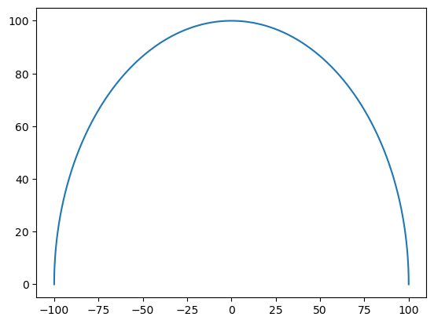

```python
def why(ex):
    return(np.sqrt(100**2 - ex**2))

ex =np.linspace(-100,100,10001)

plt.plot(ex,why(ex));
```

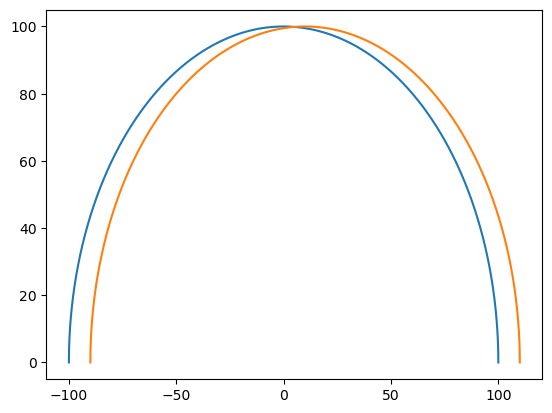

```python
plt.plot(ex,why(ex))
plt.plot(ex+10,why(ex));
```

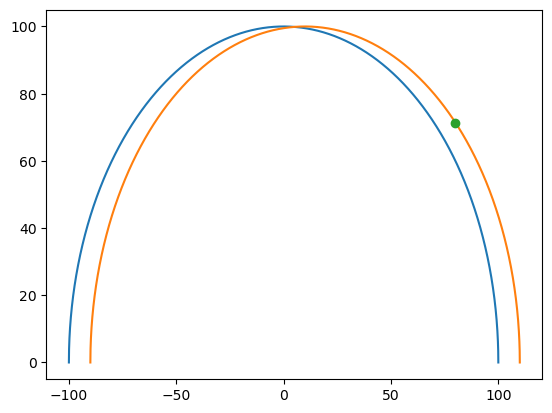

```python
plt.plot(ex,why(ex))
plt.plot(ex+10,why(ex))
plt.plot(70+10,why(70),'o')
```

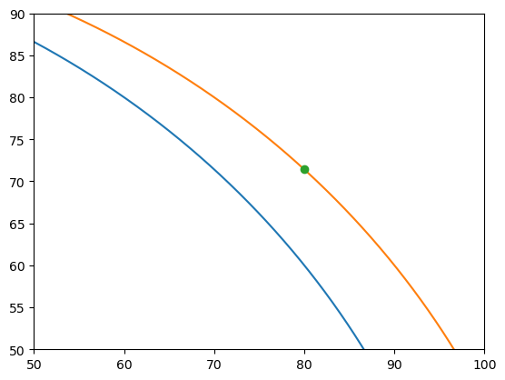

```python
plt.plot(ex,why(ex))
plt.plot(ex+10,why(ex))
plt.plot(70+10,why(70),'o')
plt.xlim(50,100),plt.ylim(50,90);
```

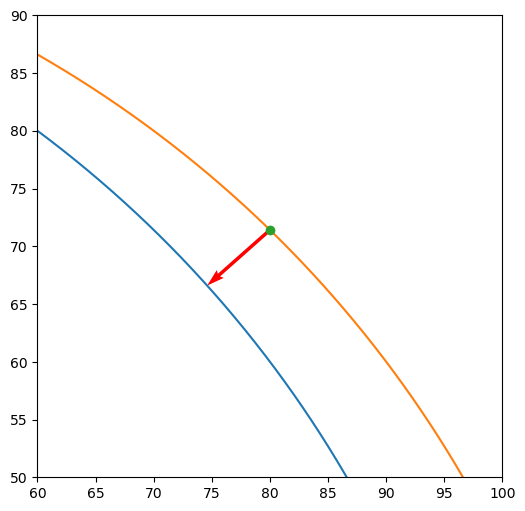

```python
plt.figure(figsize=(6,6))
plt.plot(ex,why(ex))
plt.plot(ex+10,why(ex))
plt.plot(70+10,why(70),'o')
plt.xlim(60,100),plt.ylim(50,90);
#plt.plot((74.6),(66.6),'^')
plt.quiver((70+10),why(70),74.6-80,66.6-why(70), color='r',scale=1,scale_units='xy',angles = 'xy')
```

$a^2 = b^2 +c^2 -2\:b\:c\:cos(\theta)$

$(radius+\gamma)^2 = \delta^2 +radius^2 -2\:\delta\:radius\:\Large\frac{x - \delta}{radius}$

$(radius+\gamma)^2 = \delta^2 +radius^2 -2\:\delta\:(x - \delta)$

$\gamma = \sqrt{\delta^2 +radius^2 -2\:\delta\:(x - \delta)} - radius$

```python
def gamma(ex):
    return(abs(np.sqrt(10**2 +100**2 -2*10*(ex-10))-100))
```

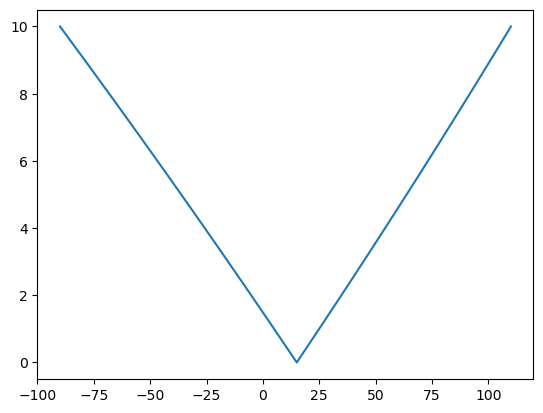

```python
plt.plot(ex+10,gamma(ex+10))
```

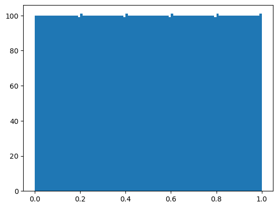

```python
plt.hist(gamma(ex+10)/10,bins=100);
```

# Small Fields

Generally a beam can be considered to be small if lateral charged particle equilibrium is not established. (As a guide, this occurs if the radius of the field is less than d_max of the beam ).

**Broad and narrow beam depth doses**

[figure not shown]

Here we see the spectra from 10x10 and 1x1 fields.  
Clearly there is a reduction in the low energy photons, they are not being scattered in and so the spectrum is harder.  
This mean higher energy is reflected in the electron distribution, which is also affected by the lack of lower energies being scattered in.

The Output Factor $\Omega$ of small fields is not just the ratio of the reading of the small field detector at the two field sizes but must include a dosimetric correction , $k^{f_{clin},f_{msr}}_{Q_{clin},Q_{msr}}$, to include known deviations due to spectral or fluence changes

$$ \Omega^{f_{clin},f_{msr}}_{Q_{clin},Q_{msr}} = \frac{M^{f_{clin}}_{w,Q_{clin}}}{M^{f_{msr}}_{w,Q_{msr}}} k^{f_{clin},f_{msr}}_{Q_{clin},Q_{msr}} $$

Obtaining accurate dose measurements in small fields can be challenging. A typical approach is to perform measurements with different detectors and come to a concensus from the variety of results obtained.

[figure not shown]